# Homework 1

### Excercise 4: Make a scatterplot of `hwy` versus `cyl`.

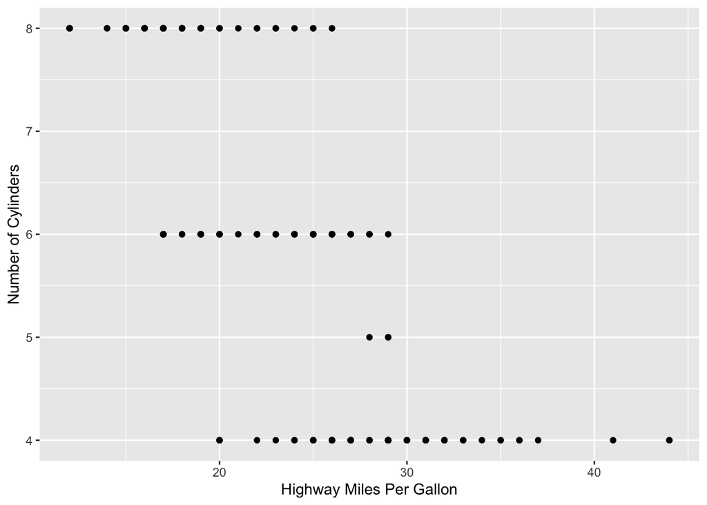

```r
ggplot(data=mpg,aes(x=hwy,y=cyl)) +
  geom_point() +
  xlab("Highway Miles Per Gallon") +
  ylab("Number of Cylinders")
```

### Excercise 5: What happens if you make a scatterplot of `class` versus `drv`? Why is the plot not useful.

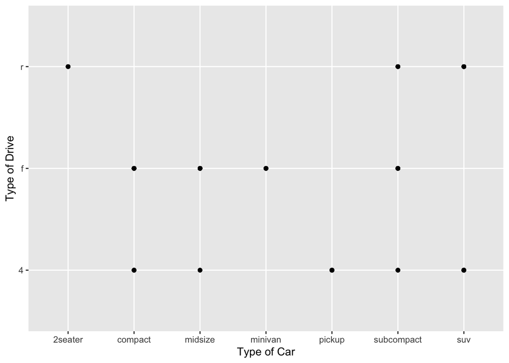

```r
ggplot(data=mpg,aes(x=class,y=drv)) +
  geom_point() +
  xlab("Type of Car") +
  ylab("Type of Drive")
```

Scatter plots are not meant to visualize the relationship between two categorical/qualitative variables.

# Chapter 1 (Pg. 12)

### Exercise 1: What’s gone wrong with this code? Why are the points not blue?

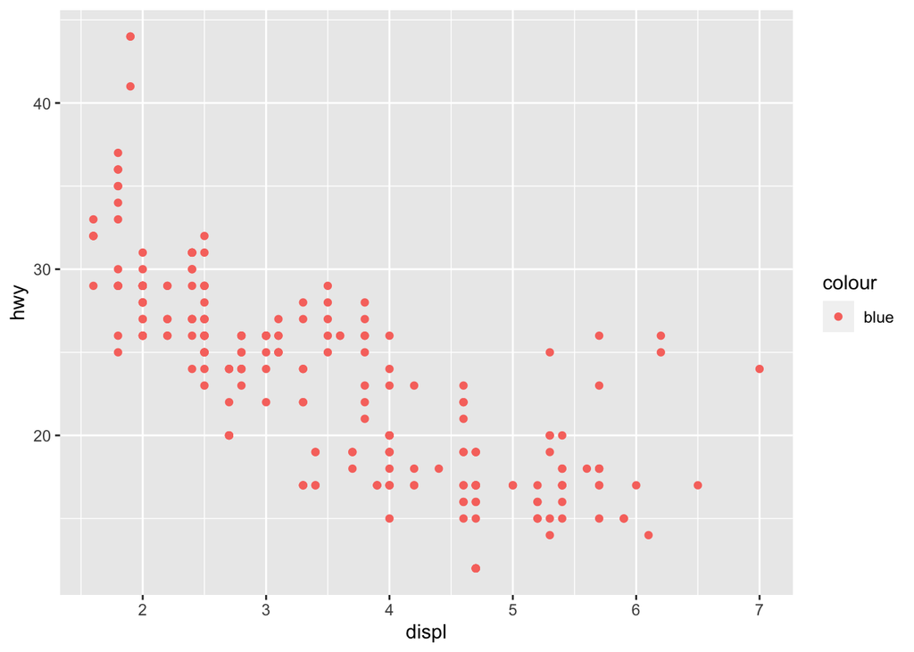

```r
ggplot(data = mpg) +
  geom_point(
    mapping = aes(x = displ, y = hwy, color = "blue")
)
```

This code does not end up working the way we intended because color is included inside the `aes()` function, which makes color the third variable in our plot. That is why we see a legend for color, and it lists all the points listed as ‘blue’ in the legend in red.

### Exercise 2: Which variables in `mpg` are categorical? Which variables are continous? How can you see this information when you run `mpg`? TODO !!!

```r
?mpg
class(mpg$cyl)
```

```
## [1] "integer"
```

Categorical Variables: 1. `manufacturer` 2. `model` 3. `trans` 4. `drv` 5. `ft` 6. `class`

Continous Discrete Variables: 1. `cyl` 2. `year`

Continous Numeric Variables: 1. `displ` 2. `cty` 3. `hwy`

### Exercise 5: What does the stroke aesthetic do? What shapes does it work with?

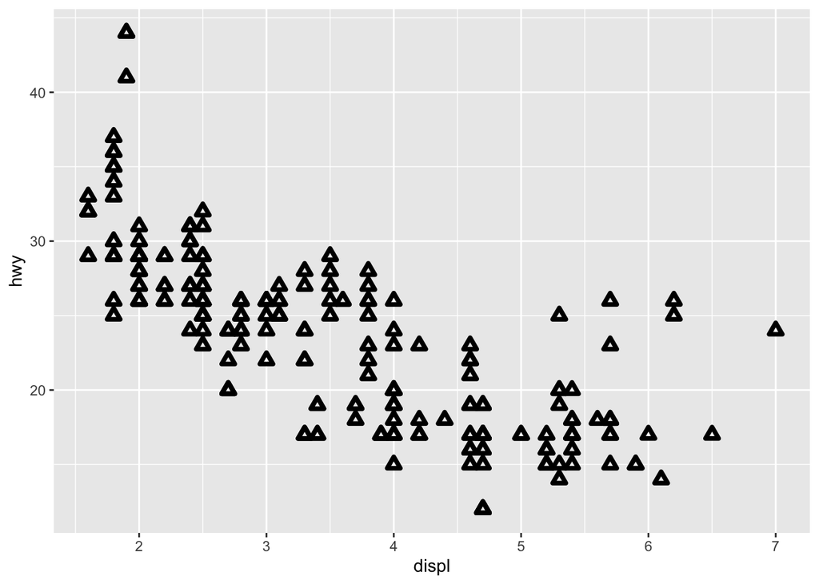

```r
?geom_point
ggplot(data = mpg) +
  geom_point(mapping = aes(x = displ, y = hwy), stroke = 2, shape = 2)
```

Stroke aesthetic is used to modify the width of the border. It works with all shapes.

# Chapter 1 (Pgs. 20-21)

### Exercise 1: What geom would you use to draw a line chart? A boxplot? A histogram? An area chart?

Line charts use `geom_line()`. Boxplots uses `geom_boxplot()`. Histogram geom uses the `geom_histogram()`. Area plot uses the `geom_area()`.

### Exercise 2: Run this code in your head and predict what the output will look like. Then, rund the code in R and check your predictions:

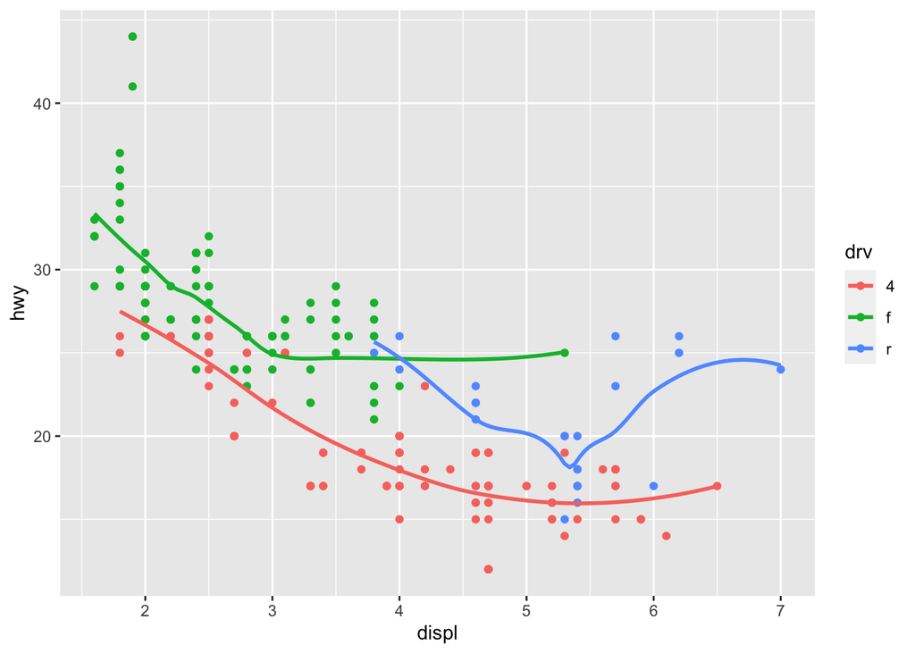

```r
ggplot(
  data = mpg,
  mapping = aes(x = displ, y = hwy, color = drv)
) +
  geom_point() +
  geom_smooth(se = FALSE)
```

For this code, we have provided the dataframe and the aesthetic mapping in the global layer. The `geom_point()` function has not been provided with any local layers, so it will just use the arguments provided in the global layer. `se_smooth()` will also use the arguments provided in the global layer, but it will also use the argument provided in the local layer, that is, `se = FALSE`. This removes the confidence interval around the smooth.

### Exercise 3: Why does show.legend = FALSE do? What happens if you remove it? Why do you think I used it earlier in the chapter?

`show.legend = FALSE` removes the legend from our plot so that it’s not visible. If we remove this line of code, we will again see the legend. This is because the value for `show.legend` is set to be TRUE by default. The author of the book had used this earlier in the chapter because they had already created a plot with the legend in it which familarized the user with the kind of data we were dealing with. So, to remove unecessarily repeated information, the author got rid of it.

### Exercise 4: What does the `se` argument to `geom_smooth()` do?

The `se` argument displays the confidence interval around smooth. It is set to be true by default. This is the gray area we see around the line.

### Exercise 5: Will these two graphs look different? Why/why not?

I don’t know if they will look different. Let me check.

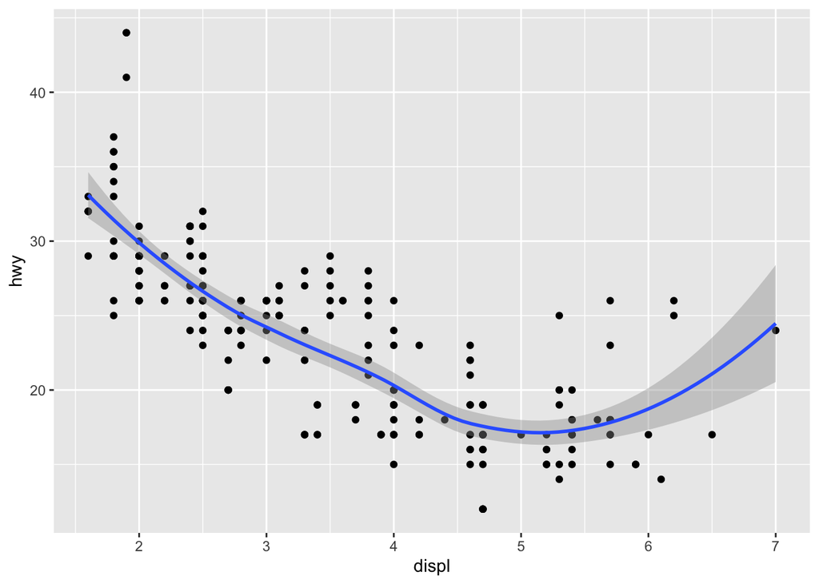

```r
ggplot(data = mpg, mapping = aes(x = displ, y = hwy)) +
  geom_point() +
  geom_smooth()
```

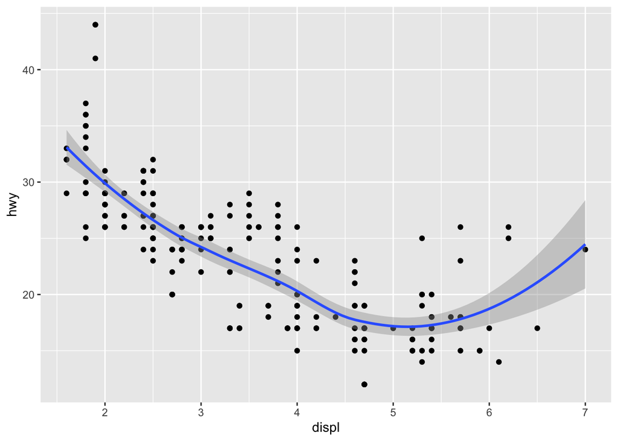

```r
ggplot() +
  geom_point(data = mpg, mapping = aes(x = displ, y = hwy)) +
  geom_smooth(data = mpg, mapping = aes(x = displ, y = hwy))
```

They do not look different. I am incredibly surprised. Well not really. It’s because in the first part of the code, we are supplying the arguments through the global layer, whereas in the second part, we are providing the same arguments to both functions locally. Effectively, both of them are doing the same thing, but the top code is better to read, at least for me.

# Open Response

For this exercise, use the **diamonds** dataset in the tidyverse. Use `?diamonds` to get more information about the dataset.

```r
?diamonds
```

## Step 1: Select 1 numeric variable and 2 categorical variables. Create a graphic using `geom_boxplot()` and `facet_wrap` to illustrate the empirical distributions of the sample.

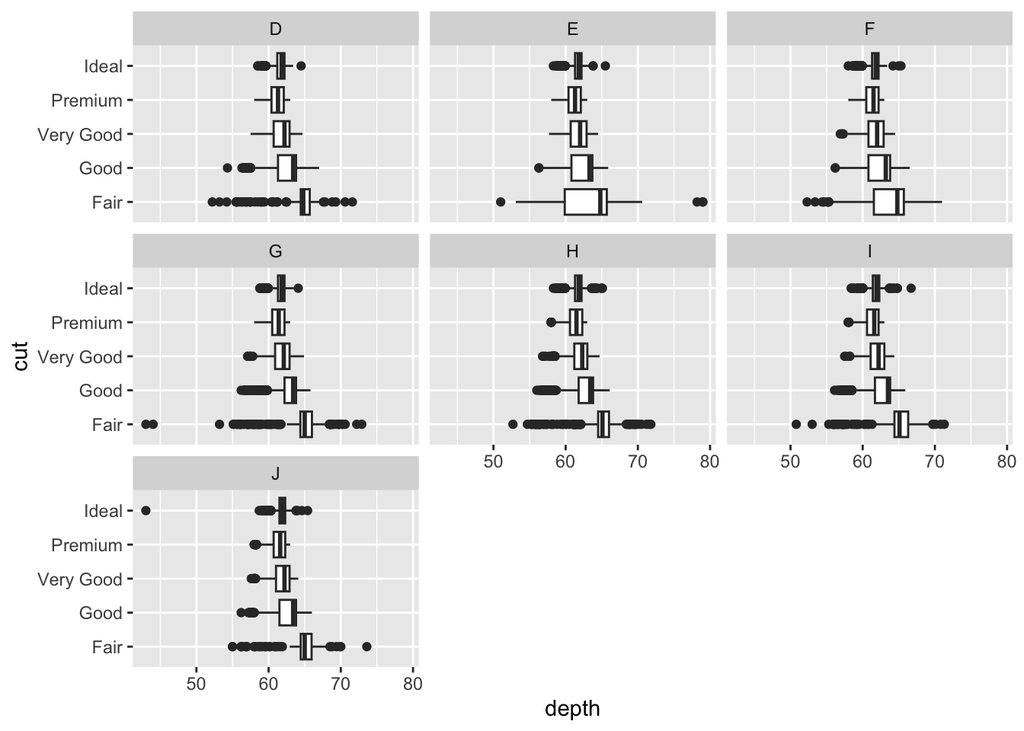

```r
ggplot(data = diamonds) +
  geom_boxplot(mapping = aes(x = depth, y = cut)) +
  facet_wrap(~ color)
```

## Step 2: Choose 2 numeric variables and 2 categorical variables and creatively illustrate the relationship between all the variables.

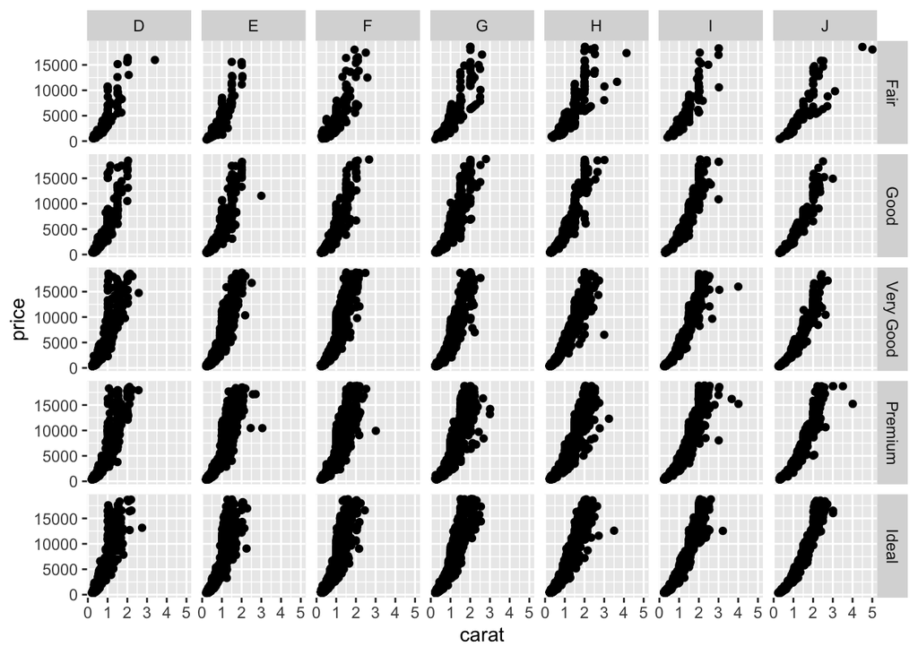

```r
ggplot(data = diamonds) +
  geom_point(mapping = aes(x = carat, y = price)) +
  facet_grid(cut ~ color)
```